# Shootings

## Summary

In 2018, there were 340 total mass shootings, altogether being 373 lives lost. Chicago was the most impacted[^1] city nationwide. The state(s) with the least number of incidents was(were) Delaware, Massachusetts, Utah. The date(s) with the most number of separate cases was(were) June 10, 2018, June 24, 2018, September 2, 2018. This data was sourced from a website with data for mass shootings that follow the FBI definition.

| state | total_killed | total_injured | impact |
| --- | --- | --- | --- |
| California | 50 | 136 | 186 |
| Florida | 48 | 132 | 180 |
| Illinois | 21 | 150 | 171 |
| Pennsylvania | 35 | 63 | 98 |
| Texas | 29 | 62 | 91 |
| Tennessee | 19 | 68 | 87 |
| Alabama | 12 | 55 | 67 |
| Louisiana | 15 | 50 | 65 |
| Missouri | 12 | 52 | 64 |
| Ohio | 13 | 46 | 59 |
| New Jersey | 4 | 54 | 58 |
| New York | 5 | 53 | 58 |
| North Carolina | 14 | 37 | 51 |
| Maryland | 13 | 31 | 44 |
| Michigan | 10 | 28 | 38 |
| Indiana | 10 | 27 | 37 |
| Colorado | 9 | 27 | 36 |
| Georgia | 3 | 33 | 36 |
| Kentucky | 7 | 25 | 32 |
| District of Columbia | 2 | 23 | 25 |
| Arkansas | 7 | 17 | 24 |
| South Carolina | 5 | 19 | 24 |
| Oklahoma | 2 | 19 | 21 |
| Virginia | 2 | 17 | 19 |
| Mississippi | 1 | 17 | 18 |
| Nevada | 3 | 15 | 18 |
| Nebraska | 1 | 16 | 17 |
| Wisconsin | 1 | 16 | 17 |
| Minnesota | 1 | 14 | 15 |
| Washington | 4 | 9 | 13 |
| Kansas | 1 | 11 | 12 |
| Arizona | 4 | 5 | 9 |
| New Mexico | 5 | 4 | 9 |
| Connecticut | 0 | 8 | 8 |
| Delaware | 5 | 0 | 5 |
| Massachusetts | 0 | 4 | 4 |
| Utah | 0 | 4 | 4 |

## Thousand Oaks Shooting

One of the incidents in 2018 that drew great attention was on November 7, 2018 at a bar in Thousand Oaks, California. Not only were there 13 killed and 2 injured, but it was noted that several of the people (consisting of many university students on a college night) who died/survived this night had previously survived the deadlist mass shooting in modern American history in 2017. Peviously known as one of the nation’s safest cities, the motive of the shooter is still unknown. Immediately after this incident, the community was also forced to evacuate their homes due to the spreading wildfire. Although this tragedy is not noted for the most death counts of 2018, it is relatively unique in its connection and sequence to other damaging events that the Thousand Oak community had to experience within such a short period of time. With the FBI and others also forced to evacuate scenes due to the fire, the motive of the shooter is still unknown.

### Figure 2: US map and Shootings

This interactive map provides the location by address of each incident, and popups provide the city the address is located in (easer geographical identification for reader rather than an address), as well as the number of deaths and injuries at that incident. The size of each incident’s circle represents the impact’s (again, calculated by the sum of killed and injured in an incident) magnitude, thereby comparing the size of each incident to others geographically.

[interactive chart not shown]

A reminder that each one of these circles represents a single incident, that although Chicago is the city most impacted, it does not mean that the circle will be the largest there since location is by address/incident. Here, we see that a great number of the incidents are on the eastern half of the United States. Larger circles also tend to be in regions/states known to have higher populations.

### Figure 3: Month vs Killed/Injured Ratio

#### Question: How does the killed/injured ratio change by the month?

Though the two variables seem independent of each other, this figure analyses the potential relationship between the month and the killed/injured ratio (derived from the total count of each within every month).

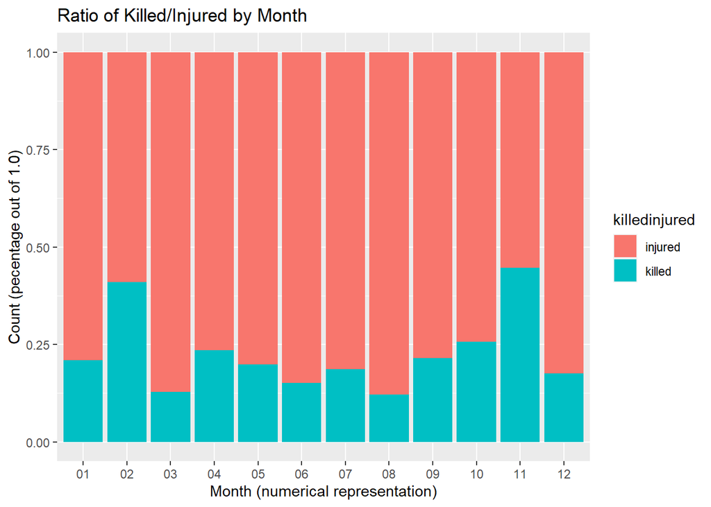

A ratio bar graph was chosen in order to visualize whether more people were killed than injured or vice versa. This way, trends of the killed ratio forming a pattern or injured ratio (both divided from the total count and in contrasting colors) are more obvious to the reader.As seen in the plot, however, there is no clear pattern besides the fact that the data seems approcimately symmetrical dividing vertically in half between the twelve months. The highest kill ratios are in Feburary (02) and November (11). However, the lack of relationship of this ratio to major holidays, seasons/climate, and other secondary variables do not seem apparent. This leads to the pending conclusion that there is no relationship between month and killed/injured ratios.

[^1]: Impact is defined as the sum of killed and injured counts for the variable mentioned.